# Final Project

# Model 2 - Decision Tree

Here I am beginning the decision tree which will take the same variables into account to predict a team’s record. A sample set is created from 75 percent of the original data which then is added into a training set and the other 25 percent is used within the test set. A prediction is then made and displayed in a matrix below. This shows an output of 33 test subjects whether they had a winning season or a losing season.

```r
nrow(df)*.75
```

```
## [1] 97.5
```

```r
sample_rows<- sample(nrow(df), nrow(df)*.75)
df_train<- df[sample_rows, ]
df_test<- df[-sample_rows, ]

football<- rpart(Record~ Yards_Allowed + Rush_Yds + Pass_Yards + Points_Allowed + Total_Points, data= df, method="class")

df_test$pred<- predict(football, df_test, type="class")

table(df_test$pred, df_test$Record)
```

```
##
##      0  1
##   0 15  0
##   1  2 16
```

A tree is formed below which displays the flow of what makes a winning record, or a winning season for a football team. It breaks down the amount of points that need to be scored, the minimum amount of points that could to be allowed to have a winning team, and the minimum total rush yards needed to be successful.

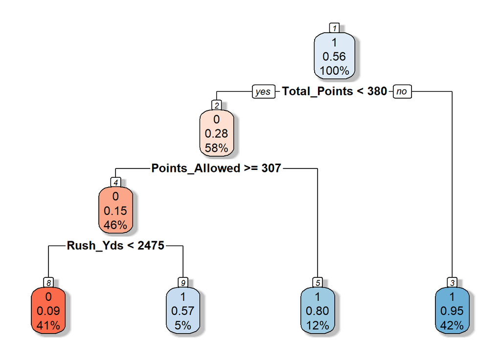

```r
rpart.plot(football, box.palette="RdBu", shadow.col="gray", nn=TRUE)
```

# Plots

Below are plots solidifying previous findings within this analysis. These two scatter plots show that as a team scores more throughout the season, the better off they are when it comes to having a successful season, or a record of 1 which is winning. The other plot shows that the lower number of points allowed also leads to a higher win percentage.

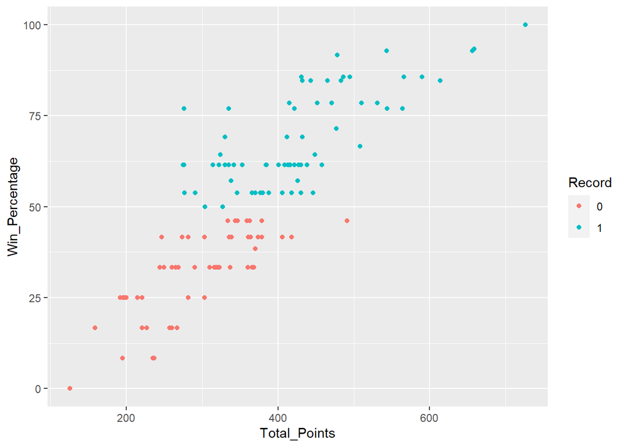

```r
s<- ggplot(data=df, aes(y=Win_Percentage, x=Total_Points, color=Record))
s+ geom_point()
```

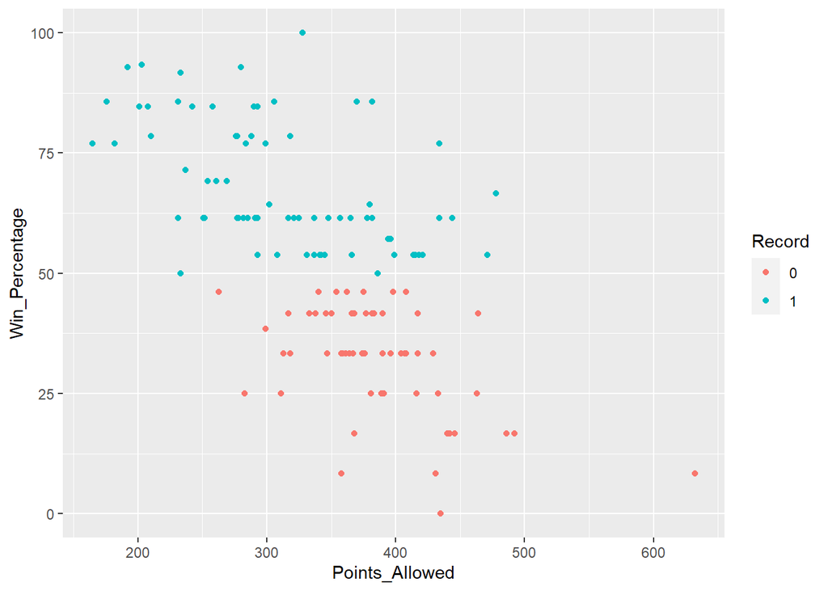

```r
s2<- ggplot(data=df, aes(y=Win_Percentage, x=Points_Allowed, color=Record))
s2+ geom_point()
```

```r
library(cowplot)
```

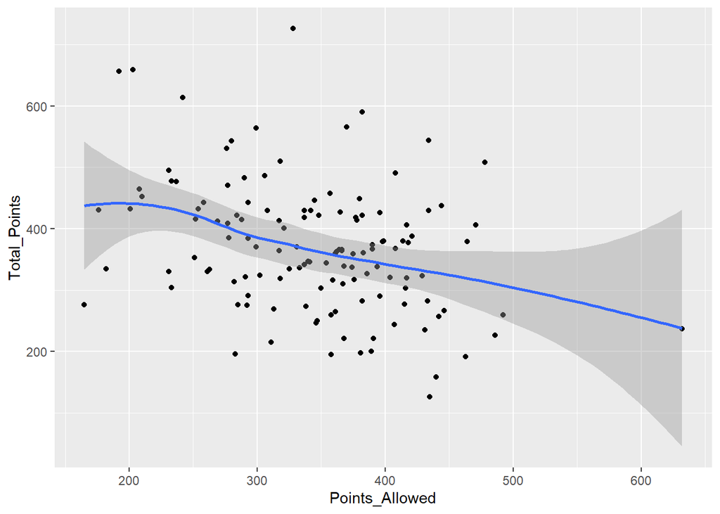

```r
scatter<- ggplot(data=df, aes(x= Points_Allowed, y= Total_Points))

scatter+ geom_point()+ geom_smooth()
```

This last plot is a simple box plot but is very effective because it shows that teams with a losing season or a 0 have a higher amount of points allowed throughout the season with an exception of some outliers. This helps strengthen the argument that defense does impact a team’s season and win percentage, however it is not the only factor impacting their record.

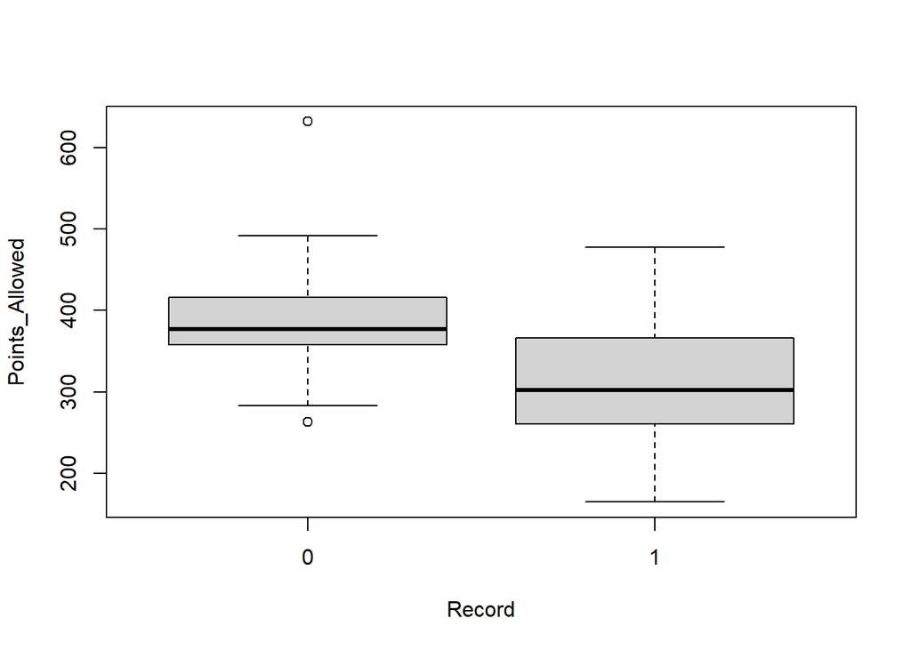

```r
boxplot(Points_Allowed ~ Record, data=df)
```